# Installation and quick start

`caROC` is an R package devoted to the assessment of continuous biomarkers. The metrics considered include **specificity at contolled sensitivity level**, **sensitivity at controlled specificity level**, and **receiver operating characteristic** (ROC) curve. If evaluation in specific sub-population is interested, all these statistics can also be computed in the version sub-population specific analysis. We allow both categorical and continuous covariates to be adjusted in computing these metrics.

## Installation and quick start

### Install caROC

Install `caROC` through

```r
library(devtools)
install_github("ziyili20/caROC")
```

### How to get help for caROC

Any caROC questions should be posted to the GitHub Issue section of caROC homepage at https://github.com/ziyili20/caROC/issues.

### Quick start on evaluating continuous biomarker with covariates adjusted

```r
library(caROC)
## get specificity at controlled sensitivity levels 0.2, 0.8, 0.9
caROC(diseaseData,controlData,formula,
      control_sensitivity = c(0.2,0.8, 0.9),
      control_specificity = NULL)

## get covariate-adjusted ROC curve with curve-based monotonizing method
curveROC <- caROC(diseaseData,controlData,formula,
            mono_resp_method = "curve",
            verbose = FALSE)
```

### Illustrating the usage of caROC in details

The tutorial is based on a simulation dataset:

```r
library(caROC)
### n1: number of cases
### n0: number of controls
n1 = n0 = 1000

## Z_D and Z_C are the covariates in the disease and control groups
Z_D1 <- rbinom(n1, size = 1, prob = 0.3)
Z_D2 <- rnorm(n1, 0.8, 1)

Z_C1 <- rbinom(n0, size = 1, prob = 0.7)
Z_C2 <- rnorm(n0, 0.8, 1)

Y_C_Z0 <- rnorm(n0, 0.1, 1)
Y_D_Z0 <- rnorm(n1, 1.1, 1)
Y_C_Z1 <- rnorm(n0, 0.2, 1)
Y_D_Z1 <- rnorm(n1, 0.9, 1)

## M0 and M1 are the outcome of interest (biomarker to be evaluated) in the control and disease groups
M0 <- Y_C_Z0 * (Z_C1 == 0) + Y_C_Z1 * (Z_C1 == 1) + Z_C2
M1 <- Y_D_Z0 * (Z_D1 == 0) + Y_D_Z1 * (Z_D1 == 1) + 1.5 * Z_D2

diseaseData <- data.frame(M = M1, Z1 = Z_D1, Z2 = Z_D2)
controlData <- data.frame(M = M0, Z1 = Z_C1, Z2 = Z_C2)

## we are interested in evaluating biomarker M while adjusting for covariate Z
userFormula = "M~Z1+Z2"
```

## 1. Covariate-adjusted sensitivity at controlled specificity level (or the reverse)

### 1.1 Compute pooled sensitivity at controlled specificed level

One can easily compute covariate-adjusted specificity at controlled sensitivity levels by specifying `control_sensitivity` and leaving `control_specificity` NULL.

```r
caROC(diseaseData,controlData,userFormula,
      control_sensitivity = c(0.2,0.8, 0.9),
      control_specificity = NULL,
      mono_resp_method = "ROC",
      whichSE = "bootstrap",nbootstrap = 100,
      CI_alpha = 0.95, logit_CI = TRUE)
```

```
#> $Estimate
#> [1] 0.959119 0.588000 0.428000
#>
#> $SE
#> [1] 0.008477755 0.030456890 0.025500792
#>
#> $ConfidenceInterval
#>                     0.2       0.8       0.9
#> LogitCI_Lower 0.9388643 0.5272961 0.3789113
#> LogitCI_Upper 0.9728572 0.6461398 0.4785482
```

To compute covariate-adjusted sensitivity at controlled specificity levels by specifying `control_specificity` and leaving `control_sensitivity` NULL.

```r
caROC(diseaseData,controlData,userFormula,
      control_sensitivity = NULL,
      control_specificity = c(0.7,0.8, 0.9),
      mono_resp_method = "none",
      whichSE = "sample",nbootstrap = 100,
      CI_alpha = 0.95, logit_CI = TRUE)
```

```
#> $Estimate
#> [1] 0.773 0.642 0.480
#>
#> $SE
#> [1] 0.01742042 0.02521579 0.02277279
#>
#> $ConfidenceInterval
#>                     0.7       0.8       0.9
#> LogitCI_Lower 0.7370608 0.5912230 0.4356429
#> LogitCI_Upper 0.8053244 0.6897792 0.5246746
```

### 1.2 Sub-population specific sensitivity at controlled specificity level

```r
target_covariates = c(1, 0.7, 0.9)

sscaROC(diseaseData,controlData,
               userFormula = userFormula,
               control_sensitivity = c(0.2,0.8, 0.9),
               target_covariates = target_covariates,
               control_specificity = NULL,
               mono_resp_method = "none",
               whichSE = "sample",nbootstrap = 100,
               CI_alpha = 0.95, logit_CI = TRUE)
```

```
#> $Estimate
#> [1] 0.9755622 0.6176939 0.4348163
#>
#> $SE
#> [1] 0.004991417 0.031733086 0.016981391
#>
#> $ConfidenceInterval
#>                     0.2       0.8       0.9
#> LogitCI_Lower 0.9636149 0.5538888 0.4018745
#> LogitCI_Upper 0.9836531 0.6776837 0.4683440
```

You can also specific covariates for multiple subpopualtions:

```r
target_covariates = matrix(c(1, 0.7, 0.9,
                      1, 0.8, 0.8), 2, 3, byrow = TRUE)
sscaROC(diseaseData,controlData,
               userFormula = userFormula,
               control_sensitivity = c(0.2,0.8, 0.9),
               target_covariates = target_covariates,
               control_specificity = NULL,
               mono_resp_method = "none",
               whichSE = "sample",nbootstrap = 100,
               CI_alpha = 0.95, logit_CI = TRUE)
```

```
#> $Estimate
#> $Estimate$`1_0.7_0.9`
#> [1] 0.9712095 0.5786200 0.3962791
#>
#> $Estimate$`1_0.8_0.8`
#> [1] 0.9712095 0.5786200 0.3962791
#>
#>
#> $SE
#> $SE$`1_0.7_0.9`
#> [1] 0.005433995 0.035956544 0.017510216
#>
#> $SE$`1_0.8_0.8`
#> [1] 0.005433995 0.035956544 0.017510216
#>
#>
#> $ConfidenceInterval
#> $ConfidenceInterval$`1_0.7_0.9`
#>                     0.2       0.8       0.9
#> LogitCI_Lower 0.9584174 0.5070172 0.3625199
#> LogitCI_Upper 0.9801479 0.6470624 0.4310563
#>
#> $ConfidenceInterval$`1_0.8_0.8`
#>                     0.2       0.8       0.9
#> LogitCI_Lower 0.9584174 0.5070172 0.3625199
#> LogitCI_Upper 0.9801479 0.6470624 0.4310563
```

## 2. Covariate-adjusted ROC curve

### 2.1 Pooled ROC

Obtaining the covariate-adjusted ROC curve with sensitivity controlled through the whole spectrum is very easy. You can choose restoring monotonicity or no restoration when constructing ROC through argument `mono_resp_method`. It could be “none” (no monotonicity restoration) or “ROC” (curve-based monotonicity restoration).

```r
### ROC with curve-based monotonicity restoration
curveROC <- caROC(diseaseData,controlData,userFormula,
                 mono_resp_method = "ROC",
                 verbose = FALSE)
```

Plot the ROC curves:

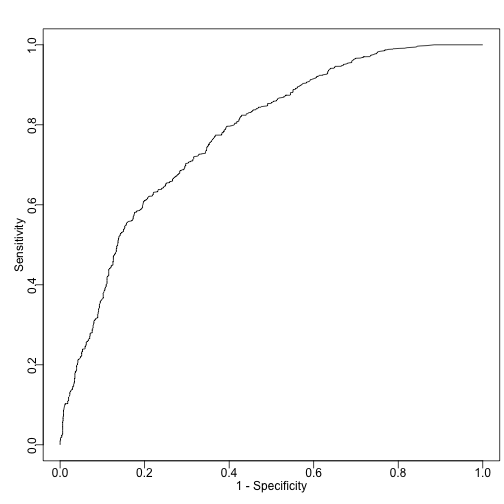

```r
oldpar <- par()
par(mar = c(3, 3, 2, 0.3), mgp = c(1.2, 0.3, 0))
plot_caROC(curveROC)
```

```r
par(oldpar)
```

Construct confidence-band for the ROC curve:

```r
curveROC_CB <- caROC_CB(diseaseData,controlData,
                        userFormula,
                        mono_resp_method = "ROC",
                        CB_alpha = 0.95,
                        nbin = 100,verbose = FALSE)
```

Plot the confidence band:

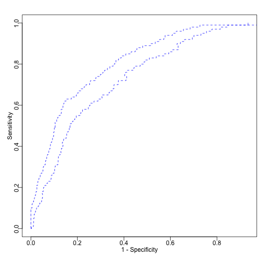

```r
oldpar <- par()
par(mar = c(3, 3, 2, 0.3), mgp = c(1.2, 0.3, 0))
plot_caROC_CB(curveROC_CB, add = FALSE, lty = 2, col = "blue")
```

```r
par(oldpar)
```

or plot the ROC and confidence band on the same plot:

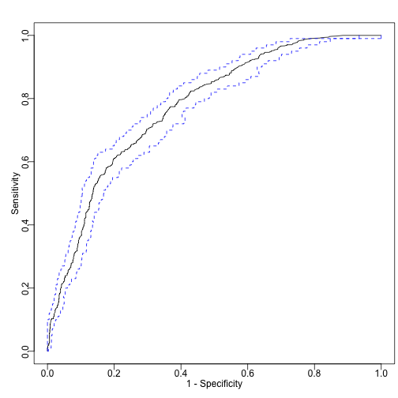

```r
oldpar <- par()
par(mar = c(3, 3, 2, 0.3), mgp = c(1.2, 0.3, 0))
plot_caROC(curveROC)
plot_caROC_CB(curveROC_CB, add = TRUE, lty = 2, col = "blue")
```

```r
par(oldpar)
```

### 2.2 Sub-population specific ROC

The ROC curve for given subpopulation can be easily calculated:

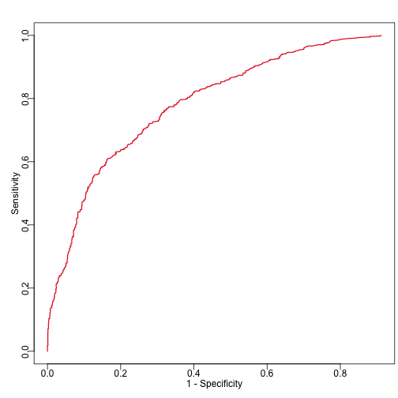

```r
target_covariates = c(1, 0.7, 0.9)
myROC <- sscaROC(diseaseData,
                 controlData,
                 userFormula,
                 target_covariates,
                 global_ROC_controlled_by = "sensitivity",
                 mono_resp_method = "none")
oldpar <- par()
par(mar = c(3, 3, 2, 0.3), mgp = c(1.2, 0.3, 0))
plot_sscaROC(myROC, lwd = 1.6)
```

```r
par(oldpar)
```

Confidence band can also be computed, but may take ~10-20min for a dataset with 2000 samples.

```r
myROCband <- sscaROC_CB(diseaseData,
                        controlData,
                        userFormula,
                        mono_resp_method = "none",
                        target_covariates,
                        global_ROC_controlled_by = "sensitivity",
                        CB_alpha = 0.95,
                        logit_CB = FALSE,
                        nbootstrap = 100,
                        nbin = 100,
                        verbose = FALSE)
oldpar <- par()
par(mar = c(3, 3, 2, 0.3), mgp = c(1.2, 0.3, 0))
plot_sscaROC_CB(myROCband, col = "purple", lty = 2)
par(oldpar)
```

[output not shown]

## 3. Threshold at controlled sensitivity/specificity for given covariate values

In clinical setting, it is useful to know the specific thresholds of biomarkers at controlled sensitivity or specificity level for given covariate values.

```r
### this is the given covariates of interest
new_covariates <- data.frame(M = 1,
                      Z1 = 0.7,
                      Z2 = 0.9)
### controlling sensitivity levels
caThreshold(userFormula, new_covariates,
            diseaseData = diseaseData,
            controlData = NULL,
            control_sensitivity = c(0.7,0.8,0.9),
            control_specificity = NULL)
```

```
#>   control_sens=0.7 control_sens=0.8 control_sens=0.9
#> 1         1.738084         1.371345        0.9148011
```

```r
### controlling specificity levels
caThreshold(userFormula,new_covariates,
            diseaseData = NULL,
            controlData = controlData,
            control_sensitivity = NULL,
            control_specificity = c(0.7,0.8,0.9))
```

```
#>   control_spec=0.7 control_spec=0.8 control_spec=0.9
#> 1         1.584796         1.945257         2.409598
```